# Crop Yield

# Impact of Cover Crops on Wheat Crop Yields

As the global population continues to increase, scientists and policymakers are looking for ways to improve our agricultural systems so that we can feed more people.

The data used in this project is adapted from the 2017 Census of Agriculture performed by the U.S. Department of Agriculture (USDA). This survey is a complete count and characterization of U.S. farms and agricultural producers. The data include various information about agricultural land area and use, farming practices, and crop yields at the county level.

There are several farming strategies that promote the long-term health of agricultural land:

```
Agricultural land easements: contracts between the government and farmers where the government pays landowners to leave areas of the land untouched.

Conservation tillage: a method that helps protect the soil surface and reduce erosion from wind and water between crop harvest and planting.

Cover crops: plants used to slow erosion, return nutrients to the soil, and help smother weeds and control pests.
```

I am to use inverse probability of treatment weighting (IPTW) to determine whether the use of cover crops causes an increase in crop yields.

# Import libraries

```r
library(palmerpenguins)
library(tidyverse)
library(cobalt)
library(WeightIt)
library(lmtest)
library(sandwich)
library(ggplot2)
```

# Data Exploration

```r
# Load file as dataframe
farm_df <- read.csv("farms.csv")
```

```r
# Inspect dataframe
head(farm_df)
```

|  | total_yield | cover_10 | region | total_avg | age_avg | experience_avg | insurance_avg | easement_p | conservation_till_avg | fertilizer_per_area | X |
| --- | --- | --- | --- | --- | --- | --- | --- | --- | --- | --- | --- |
| 1 | 61.33234 | 0 | South | 0.305 | 57.2 | 21.6 | 0.2543968 | 1.8867925 | 145 | 20.26741 | NA |
| 2 | 47.47099 | 1 | South | 0.208 | 61.2 | 24.9 | 0.6386207 | 1.5439430 | 553 | 74.62687 | NA |
| 3 | 46.27485 | 0 | South | 0.307 | 61.0 | 24.5 | 0.4223478 | 0.8032129 | 63 | 15.08367 | NA |
| 4 | 81.77405 | 0 | South | 0.254 | 58.8 | 23.9 | 1.0557846 | 1.1844332 | 391 | 60.03353 | NA |
| 5 | 81.04827 | 0 | South | 0.117 | 58.0 | 23.9 | 0.2556000 | 0.5053341 | 27 | 22.93760 | NA |
| 6 | 58.26087 | 0 | South | 0.292 | 62.5 | 23.6 | 0.6138043 | 2.3454158 | 579 | 25.26148 | NA |

# Initial data observations

Outcome:

```
total_yield: represents the average total yield of wheat in bushels per acre.
```

Treatment:

```
cover_10: indicates whether at least 10% of farms in a county employ cover crops.
```

Predictors:

```
region: geographic region where the county is located.

total_avg: average total size of farms (thousands of acres).

age_avg: average age of the primary farm operator (years).

experience_avg: average number of years of farming experience of the primary farm operator (years).

insurance_avg: average area of land with crop insurance (thousands of acres).

easement_p: indicates the average percent of land under an easement in the county.

conservation_till_avg: average area of land that uses conservation tillage methods (acres).

fertilizer_per_area: average cost of fertilizers used per acre (hundreds of thousands of dollars).
```

# Examine Initial Overlap and Balance

Assess overlap and balance visually for a couple of variables to compare counties with AT LEAST 10% of farms using cover crops and counties with LESS THAN 10% of farms using cover crops.

I will use a balance plot for the age_avg variable.

Do the treatment and control distributions appear to be centered in the same location and have similar spreads?

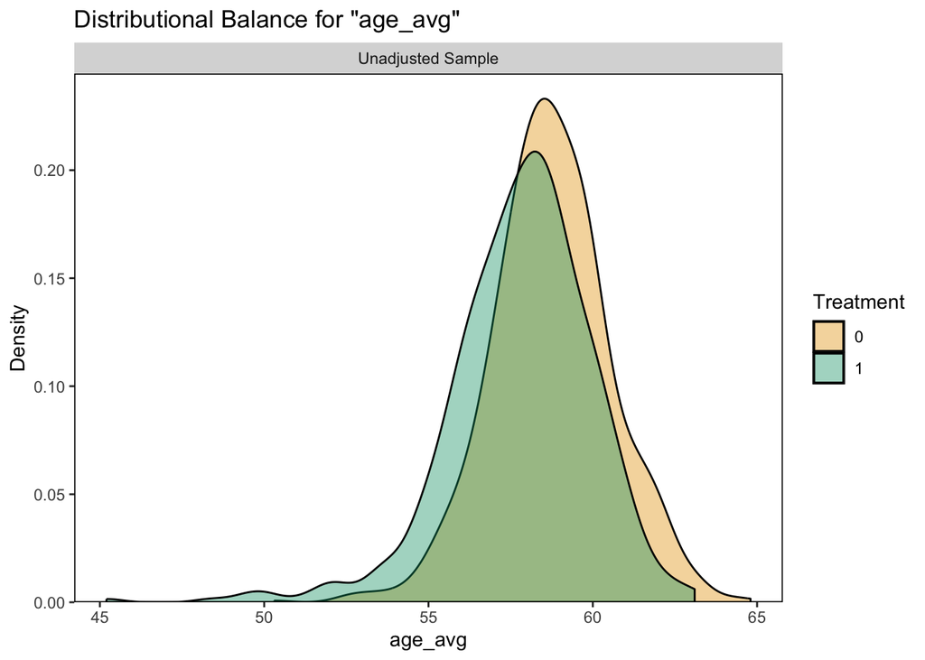

```r
# Balance plot for the average age
bal.plot(
  x = cover_10 ~ age_avg, #formula
  data = farm_df, #dataset
  var.name = "age_avg", #variable
  colors = c("#E69F00", "#009E73") #set fill colors
)
```

Are the proportions of counties in the treatment versus control groups similar across the four regions?

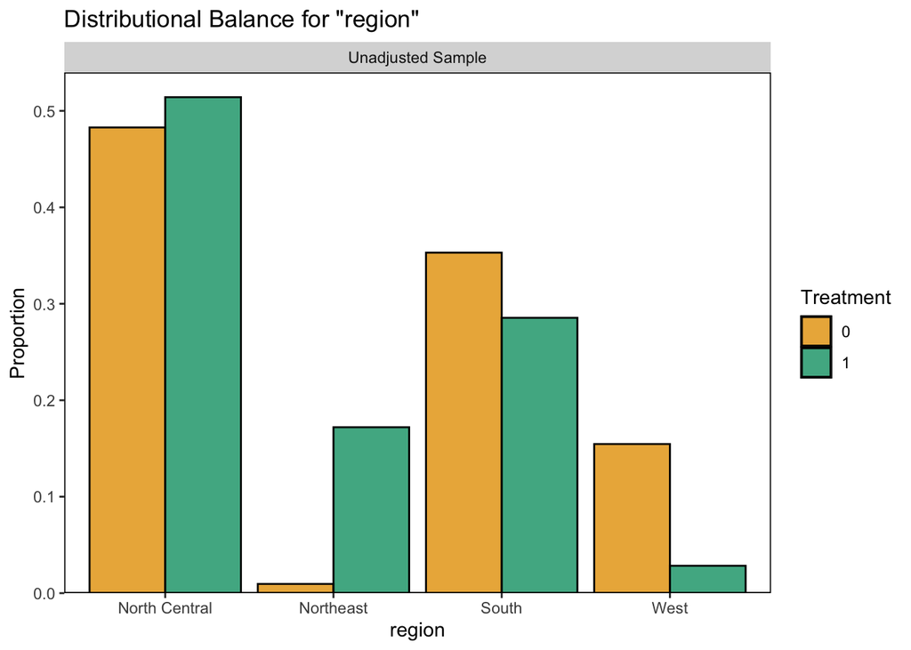

```r
# Balance plot for region
bal.plot(
  x = cover_10 ~ region, #formula
  data = farm_df, #dataset
  var.name = "region", #variable
  colors = c("#E69F00", "#009E73") #set fill colors
)
```

```r
# Balance table to show standardized mean differences (SMD) and variance ratios
bal.tab(
  x = cover_10 ~ age_avg + region, data = farm_df,
  binary = "std", disp.v.ratio = TRUE
)
```

```
Note: `s.d.denom` not specified; assuming "pooled".
```

```
Balance Measures
                        Type Diff.Un V.Ratio.Un
age_avg              Contin. -0.4668     1.4521
region_North Central  Binary  0.0627          .
region_Northeast      Binary  0.5896          .
region_South          Binary -0.1454          .
region_West           Binary -0.4488          .

Sample sizes
    Control Treated
All    1048     529
```

# Perform IPTW Procedure and Re-check Balance

Perform the inverse probability of treatment weighting (IPTW) procedure to see if we can minimize imbalance between the treatment groups before estimating the causal treatment effect.”

“Next, perform an IPTW procedure using region, average farm size, average number of farms with crop insurance, and average cost of fertilizer per acre as predictors in the propensity score model. Calculate weights in order to estimate the average treatment effect (ATE).

```r
farm_iptw <- weightit(
  formula = cover_10 ~ region +
    total_avg + insurance_avg + fertilizer_per_area,
  data = farm_df, method = "ps", estimand = "ATE"
)

farm_iptw
```

```
A weightit object
 - method: "glm" (propensity score weighting with GLM)
 - number of obs.: 1577
 - sampling weights: none
 - treatment: 2-category
 - estimand: ATE
 - covariates: region, total_avg, insurance_avg, fertilizer_per_area
```

Create a Love plot showing the SMD between treatment groups for each variable in the propensity score model. Display the SMD for binary variables and the SMD threshold of ± 0.1.

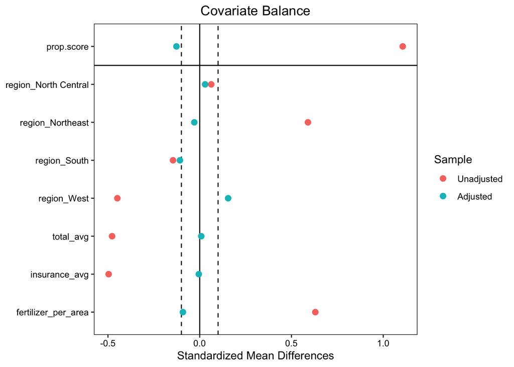

```r
# Love plot showing the SMD
# between treatment groups for each variable in the propensity score model
love.plot(
  farm_iptw, binary = "std", thresholds = c(m = 0.1)
)
```

# Refine Propensity Score Model

Can I improve the balance by tuning the propensity score model?

Re-run the IPTW procedure with a new propensity score model. Achieve this by removing the fertilizer_per_area variable from the model. Then add varibles:

- the average age of the primary producer
- the average experience of the primary producer
- the average percent of land under easement
- the average number of farms using conservation tillage

```r
farm_iptw2 <- farm_iptw2 <- weightit(
  formula = cover_10 ~ region + total_avg
  + age_avg + experience_avg
  + easement_p + conservation_till_avg
  + insurance_avg,
  data = farm_df, method = "ps", estimand = "ATE"
)

farm_iptw2
```

```
A weightit object
 - method: "glm" (propensity score weighting with GLM)
 - number of obs.: 1577
 - sampling weights: none
 - treatment: 2-category
 - estimand: ATE
 - covariates: region, total_avg, age_avg, experience_avg, easement_p, conservation_till_avg, insurance_avg
```

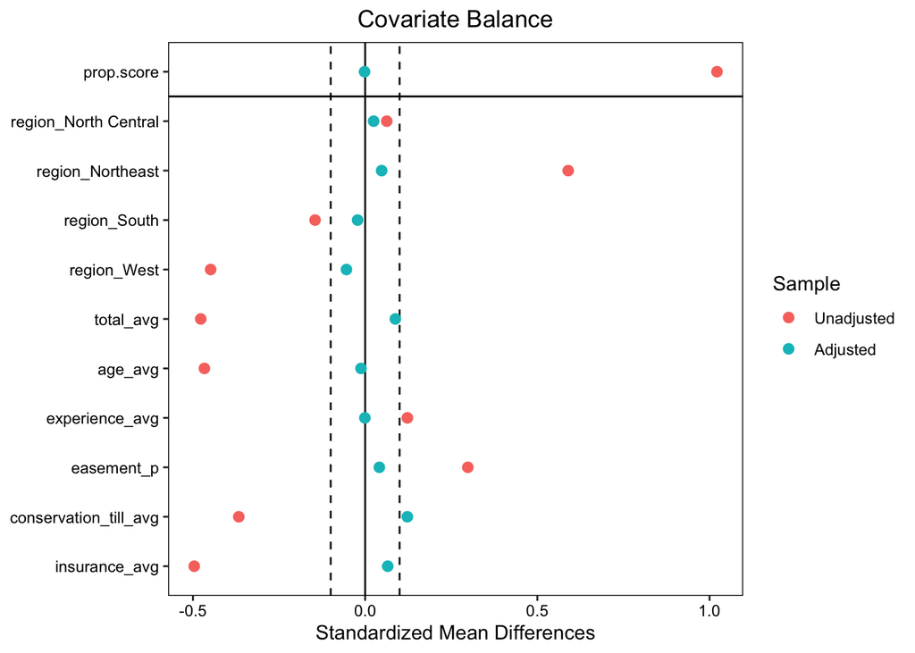

```r
# Love plot showing the SMD between
# treatment groups for each variable
# in the propensity score model
love.plot(
  farm_iptw2, binary = "std", thresholds = c(m = 0.1)
)
```

The Love plot shows SMD values closer to zero than the previous model.

Next, inspect the distribution of propensity scores between treatment groups to measue IPTW procedure performance.

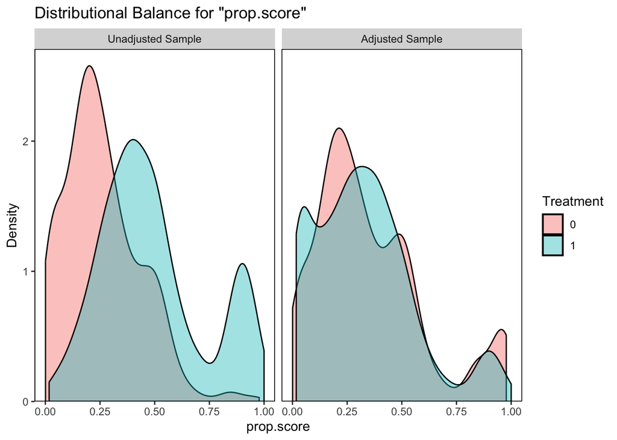

```r
# Generate a balance plot to display
# the distribution of propensity scores in each treatment group before
# AND after the weighting process
bal.plot(
  x = farm_iptw, var.name = "prop.score", which = "both"
)
```

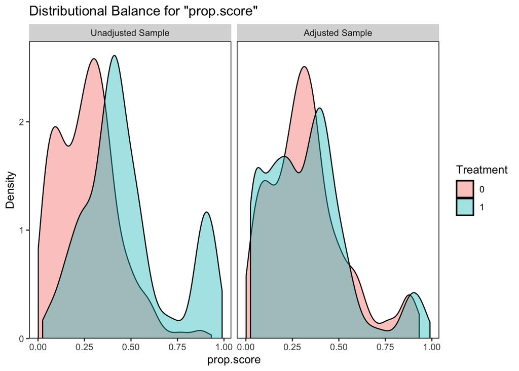

```r
bal.plot(
  x = farm_iptw2, var.name = "prop.score", which = "both"
)
```

Do the distributions of the weighted propensity scores look closer to identical, and are they overlapping each other?

# Estimate Causal Treatment Effect

Last step of the analysis:

- Fit the final outcome model to estimate the causal effect of cover crop usage on crop yields.
1. Fit the outcome regression model with total crop yield as the outcome, cover crop usage as the treatment variable, and the other variables from the second propensity score model as the additional predictors.
- Include the weights from the IPTW procedure in the regression model.

```r
yield_mod <- glm(
  total_yield ~ cover_10 + region
  + total_avg + age_avg
  + experience_avg + easement_p
  + conservation_till_avg + insurance_avg,
  data = farm_df, weights = farm_iptw$weights
)
```

When IPTW is used to estimate the causal treatment effect, a robust standard error estimate is required.

Estimate the regression parameters for the weighted regression model using the coeftest() function. Incorporate a robust standard error estimator from the sandwich package.

```r
# Estimate regression coefficients
# for weighted outcome model with
# robust standard errors
coeftest(
  yield_mod, vcov. = vcovHC
)
```

```
z test of coefficients:

                         Estimate  Std. Error z value  Pr(>|z|)
(Intercept)            76.1142499  24.6828383  3.0837  0.002044 **
cover_10                1.9886231   1.4934535  1.3316  0.183005
regionNortheast        -6.3547797   3.0163285 -2.1068  0.035136 *
regionSouth            -2.4664347   1.7622114 -1.3996  0.161626
regionWest             29.0362541   7.3190074  3.9672 7.271e-05 ***
total_avg             -18.3031271   4.1958919 -4.3622 1.288e-05 ***
age_avg                -1.3897752   0.3423629 -4.0594 4.921e-05 ***
experience_avg          2.6499890   0.5098620  5.1975 2.020e-07 ***
easement_p              0.9634769   0.5622901  1.7135  0.086623 .
conservation_till_avg  -0.0083884   0.0046259 -1.8134  0.069776 .
insurance_avg           6.3677396   4.6788799  1.3610  0.173528
---
Signif. codes:  0 '***' 0.001 '**' 0.01 '*' 0.05 '.' 0.1 ' ' 1
```